# Practical II

Katherine Filpo

5/9/2020

### Word Equation

Apple Rust ~ Wrapping + Temperature +Wrapping:Temperature OR Virus ~ Wrapped + Temp + Wrapped:Temp

### Hypothesis

*H<sub>01</sub>:* The interaction between wrapping and temeperature of the apple will not affect the apple rust.

*H<sub>02</sub>:* The temperature of the apple will not affect apple rust.

*H<sub>03</sub>:* The wrapping of the apple will not affect apple rust.

### Full Analysis

```r
model_1 <-lm(VIRUS~TEMP+WRAPPED+WRAPPED:factor(TEMP),data=apple)
anova(model_1)
```

```
## Analysis of Variance Table
##
## Response: VIRUS
##                      Df Sum Sq Mean Sq F value  Pr(>F)
## TEMP                  1 160.32 160.321  5.3540 0.03920 *
## WRAPPED               1  12.50  12.500  0.4174 0.53038
## WRAPPED:factor(TEMP)  3 270.35  90.115  3.0094 0.07223 .
## Residuals            12 359.33  29.944
## ---
## Signif. codes:  0 '***' 0.001 '**' 0.01 '*' 0.05 '.' 0.1 ' ' 1
```

Temp is a continuous variable:

```r
model_2<- lm(VIRUS ~ factor(WRAPPED) * TEMP, data = apple)
anova(model_2)
```

```
## Analysis of Variance Table
##
## Response: VIRUS
##                      Df Sum Sq Mean Sq F value Pr(>F)
## factor(WRAPPED)       1  12.50  12.500  0.2798 0.6051
## TEMP                  1 160.32 160.321  3.5891 0.0790 .
## factor(WRAPPED):TEMP  1   4.32   4.321  0.0967 0.7604
## Residuals            14 625.36  44.668
## ---
## Signif. codes:  0 '***' 0.001 '**' 0.01 '*' 0.05 '.' 0.1 ' ' 1
```

No interaction betwen temp and wrapping:

```r
model_3<- lm(VIRUS ~ factor(WRAPPED) + factor(TEMP), data = apple)
anova(model_3)
```

```
## Analysis of Variance Table
##
## Response: VIRUS
##                 Df Sum Sq Mean Sq F value   Pr(>F)
## factor(WRAPPED)  1  12.50  12.500  0.4379 0.518898
## factor(TEMP)     2 390.33 195.167  6.8365 0.008482 **
## Residuals       14 399.67  28.548
## ---
## Signif. codes:  0 '***' 0.001 '**' 0.01 '*' 0.05 '.' 0.1 ' ' 1
```

*Model Opimizing*

```r
anova(model_1, model_2)
```

```
## Analysis of Variance Table
##
## Model 1: VIRUS ~ TEMP + WRAPPED + WRAPPED:factor(TEMP)
## Model 2: VIRUS ~ factor(WRAPPED) * TEMP
##   Res.Df    RSS Df Sum of Sq     F  Pr(>F)
## 1     12 359.33
## 2     14 625.36 -2   -266.02 4.442 0.03599 *
## ---
## Signif. codes:  0 '***' 0.001 '**' 0.01 '*' 0.05 '.' 0.1 ' ' 1
```

```r
anova(model_1, model_3)
```

```
## Analysis of Variance Table
##
## Model 1: VIRUS ~ TEMP + WRAPPED + WRAPPED:factor(TEMP)
## Model 2: VIRUS ~ factor(WRAPPED) + factor(TEMP)
##   Res.Df    RSS Df Sum of Sq      F Pr(>F)
## 1     12 359.33
## 2     14 399.67 -2   -40.333 0.6735 0.5282
```

*Testing Residuals and Homogeneity of Variance*

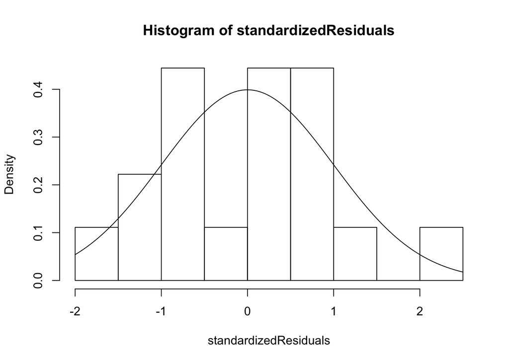

```r
unstandardizedPredicted <- predict(model_1)
unstandardizedResiduals <- resid(model_1)

standardizedPredicted <- (unstandardizedPredicted - mean(unstandardizedPredicted)) / sd(unstandardizedPredicted)
standardizedResiduals <- (unstandardizedResiduals - mean(unstandardizedResiduals)) / sd(unstandardizedResiduals)

hist(standardizedResiduals, freq = FALSE)
curve(dnorm, add = TRUE)
```

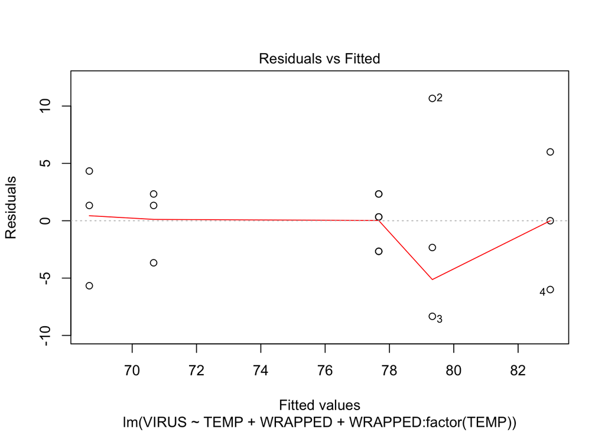

```r
plot(model_1, which =c(1,1))
```

The assumptions of Model_1 are sound. The standardized residuals and homogenitity of variance are as expected.

### Conclusions + Graphs

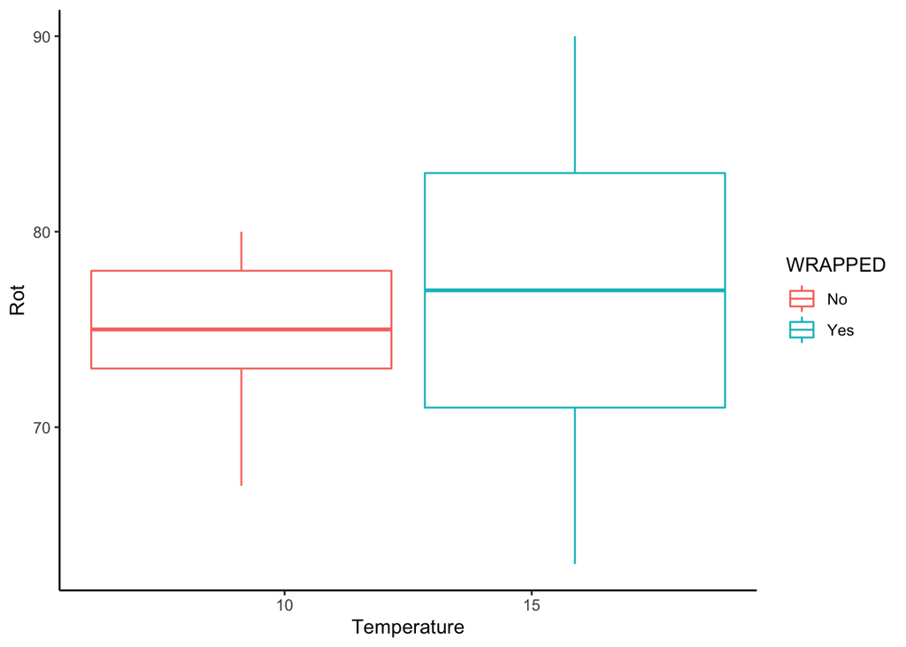

```r
Fig1<-ggplot(apple, aes(x=TEMP, y=VIRUS,colour=WRAPPED, group=WRAPPED)) +
  geom_boxplot()+
  theme_classic()+
  xlab("Temperature")+ylab("Rot") +
  theme_classic()
Fig1
```

I would recommend that the Apple Orchardist American Association store their apples at a cooler temperature. Whether they are wrapped or not does not have a significant effect on the apple rot levels.